# Assignment_6

Kai Ellis

March 6, 2020

1. The data are in: BirdsInForestPatches.csv, and recall from the last assignment that you log10- transformed fragment area, distance to nearest forest patch and distance to largest forest patch. You’ll those log10-transformed predictors again here.

```r
birdDat <- read.csv("/Users/kelli/Desktop/Biol343/Assignment6/BirdsInForestPatches.csv")

summary(birdDat)
```

```
##   ï..abundance      area_ha           yr_isol     dist_nearest_km
##  Min.   : 1.50   Min.   :   0.10   Min.   :1890   Min.   :  26.0
##  1st Qu.:12.40   1st Qu.:   2.00   1st Qu.:1928   1st Qu.:  93.0
##  Median :21.05   Median :   7.50   Median :1962   Median : 234.0
##  Mean   :19.51   Mean   :  69.27   Mean   :1950   Mean   : 240.4
##  3rd Qu.:28.30   3rd Qu.:  29.75   3rd Qu.:1966   3rd Qu.: 333.2
##  Max.   :39.60   Max.   :1771.00   Max.   :1976   Max.   :1427.0
##  dist_large_km       grazing      altitude_masl
##  Min.   :  26.0   Min.   :1.000   Min.   : 60.0
##  1st Qu.: 158.2   1st Qu.:2.000   1st Qu.:120.0
##  Median : 338.5   Median :3.000   Median :140.0
##  Mean   : 733.3   Mean   :2.982   Mean   :146.2
##  3rd Qu.: 913.8   3rd Qu.:4.000   3rd Qu.:182.5
##  Max.   :4426.0   Max.   :5.000   Max.   :260.0
```

```r
birdDat <- birdDat %>% mutate(logArea = log10(area_ha),
                              logLarge = log10(dist_large_km),
                              logNear = log10(dist_nearest_km),
                              nyrs_isol = 1985-yr_isol)
#this column had a bugged name, fixed it
names(birdDat)[names(birdDat)=="ï..abundance"] <- "abundance"
```

2. Perform backwards selection using the protocol we developed in lecture. Start with the full model and eliminate one predictor at a time chosen as the predictor with the highest P value from an analysis using car::Anova(). Larger and smaller models should be compared using likelihood-ratio tests implemented with anova().

```r
full <- lm(abundance~ grazing + altitude_masl + logArea + logLarge + logNear + nyrs_isol ,
                   data = birdDat)

Anova(full) #logLarge largest P value at 0.76
```

```
## Anova Table (Type II tests)
##
## Response: abundance
##                Sum Sq Df F value    Pr(>F)
## grazing        131.07  1  3.2163   0.07908 .
## altitude_masl   27.02  1  0.6630   0.41945
## logArea       1059.75  1 26.0049 5.494e-06 ***
## logLarge         3.80  1  0.0933   0.76130
## logNear          4.68  1  0.1149   0.73609
## nyrs_isol      108.83  1  2.6705   0.10864
## Residuals     1996.85 49
## ---
## Signif. codes:  0 '***' 0.001 '**' 0.01 '*' 0.05 '.' 0.1 ' ' 1
```

```r
noLarge <- lm(abundance~ grazing + altitude_masl + logArea + logNear + nyrs_isol ,data =
                        birdDat)

anova(full, noLarge) #no sig p, keep going
```

```
## Analysis of Variance Table
##
## Model 1: abundance ~ grazing + altitude_masl + logArea + logLarge + logNear +
##     nyrs_isol
## Model 2: abundance ~ grazing + altitude_masl + logArea + logNear + nyrs_isol
##   Res.Df    RSS Df Sum of Sq      F Pr(>F)
## 1     49 1996.8
## 2     50 2000.7 -1   -3.8027 0.0933 0.7613
```

```r
Anova(noLarge) #logLarge largest P value at 0.576
```

```
## Anova Table (Type II tests)
##
## Response: abundance
##                Sum Sq Df F value    Pr(>F)
## grazing        132.44  1  3.3098   0.07486 .
## altitude_masl   35.12  1  0.8778   0.35331
## logArea       1193.04  1 29.8161 1.489e-06 ***
## logNear         12.64  1  0.3159   0.57661
## nyrs_isol      121.64  1  3.0399   0.08739 .
## Residuals     2000.66 50
## ---
## Signif. codes:  0 '***' 0.001 '**' 0.01 '*' 0.05 '.' 0.1 ' ' 1
```

```r
noNear <- lm(abundance~ grazing + altitude_masl + logArea  + nyrs_isol ,data =
                        birdDat)

anova( noLarge, noNear)#no sig p, keep going
```

```
## Analysis of Variance Table
##
## Model 1: abundance ~ grazing + altitude_masl + logArea + logNear + nyrs_isol
## Model 2: abundance ~ grazing + altitude_masl + logArea + nyrs_isol
##   Res.Df    RSS Df Sum of Sq      F Pr(>F)
## 1     50 2000.7
## 2     51 2013.3 -1   -12.639 0.3159 0.5766
```

```r
Anova(noNear) #altitude_masl largest p at 0.231
```

```
## Anova Table (Type II tests)
##
## Response: abundance
##                Sum Sq Df F value    Pr(>F)
## grazing        123.48  1  3.1280   0.08294 .
## altitude_masl   57.84  1  1.4653   0.23167
## logArea       1227.11  1 31.0846 9.412e-07 ***
## nyrs_isol      134.89  1  3.4169   0.07033 .
## Residuals     2013.29 51
## ---
## Signif. codes:  0 '***' 0.001 '**' 0.01 '*' 0.05 '.' 0.1 ' ' 1
```

```r
noAlt <- lm(abundance~ grazing + logArea  + nyrs_isol ,data =
                        birdDat)

anova(noNear, noAlt)#no sig p, keep going
```

```
## Analysis of Variance Table
##
## Model 1: abundance ~ grazing + altitude_masl + logArea + nyrs_isol
## Model 2: abundance ~ grazing + logArea + nyrs_isol
##   Res.Df    RSS Df Sum of Sq      F Pr(>F)
## 1     51 2013.3
## 2     52 2071.1 -1   -57.844 1.4653 0.2317
```

```r
Anova(noAlt) #nyrs_isol largest p at 0.0768
```

```
## Anova Table (Type II tests)
##
## Response: abundance
##            Sum Sq Df F value    Pr(>F)
## grazing    188.45  1  4.7315   0.03418 *
## logArea   1262.97  1 31.7094 7.316e-07 ***
## nyrs_isol  129.81  1  3.2590   0.07682 .
## Residuals 2071.14 52
## ---
## Signif. codes:  0 '***' 0.001 '**' 0.01 '*' 0.05 '.' 0.1 ' ' 1
```

```r
noIsol <- lm(abundance~ grazing + logArea ,data = birdDat)

anova(noAlt, noIsol) #no sig p, keep going
```

```
## Analysis of Variance Table
##
## Model 1: abundance ~ grazing + logArea + nyrs_isol
## Model 2: abundance ~ grazing + logArea
##   Res.Df    RSS Df Sum of Sq     F  Pr(>F)
## 1     52 2071.1
## 2     53 2200.9 -1   -129.81 3.259 0.07682 .
## ---
## Signif. codes:  0 '***' 0.001 '**' 0.01 '*' 0.05 '.' 0.1 ' ' 1
```

```r
Anova(noIsol) #grazing largest p at 0.0001946, probably gonna stop with noIsol but I'll test anyway.
```

```
## Anova Table (Type II tests)
##
## Response: abundance
##           Sum Sq Df F value    Pr(>F)
## grazing    666.0  1  16.038 0.0001946 ***
## logArea   1184.6  1  28.527 1.977e-06 ***
## Residuals 2200.9 53
## ---
## Signif. codes:  0 '***' 0.001 '**' 0.01 '*' 0.05 '.' 0.1 ' ' 1
```

```r
noGraze <- lm(abundance~ logArea ,data =
                        birdDat)

anova(noIsol,noGraze) #sig P, noIsol is MAM
```

```
## Analysis of Variance Table
##
## Model 1: abundance ~ grazing + logArea
## Model 2: abundance ~ logArea
##   Res.Df    RSS Df Sum of Sq      F    Pr(>F)
## 1     53 2200.9
## 2     54 2866.9 -1      -666 16.038 0.0001946 ***
## ---
## Signif. codes:  0 '***' 0.001 '**' 0.01 '*' 0.05 '.' 0.1 ' ' 1
```

```r
rm(noAlt, noGraze, noLarge, noNear) #remove all non-full or MAM models to clean up the global enviroment
```

3. Once you’ve arrived at the MAM, see if you get the same model using forward selection implemented by the add1() function.

```r
null <- lm(abundance~1, data=birdDat)
add1(null,scope = ~grazing + altitude_masl + logArea + logLarge + logNear + nyrs_isol, test = "F") #logArea has lowest p value, add it to the model
```

```
## Single term additions
##
## Model:
## abundance ~ 1
##               Df Sum of Sq    RSS    AIC F value    Pr(>F)
## <none>                     6337.9 266.82
## grazing        1    2952.3 3385.6 233.71 47.0899 6.897e-09 ***
## altitude_masl  1     943.5 5394.4 259.80  9.4450  0.003316 **
## logArea        1    3471.0 2866.9 224.40 65.3774 7.178e-11 ***
## logLarge       1      88.4 6249.5 268.04  0.7641  0.385905
## logNear        1     101.8 6236.1 267.92  0.8813  0.352018
## nyrs_isol      1    1605.8 4732.1 252.46 18.3249 7.678e-05 ***
## ---
## Signif. codes:  0 '***' 0.001 '**' 0.01 '*' 0.05 '.' 0.1 ' ' 1
```

```r
add1(update(null,~.+logArea), scope = ~ grazing + altitude_masl + logArea + logLarge + logNear + nyrs_isol, test = "F")
```

```
## Single term additions
##
## Model:
## abundance ~ logArea
##               Df Sum of Sq    RSS    AIC F value    Pr(>F)
## <none>                     2866.9 224.40
## grazing        1    666.00 2200.9 211.59 16.0376 0.0001946 ***
## altitude_masl  1    227.68 2639.3 221.76  4.5722 0.0371233 *
## logLarge       1    201.93 2665.0 222.31  4.0159 0.0501960 .
## logNear        1     65.48 2801.5 225.10  1.2388 0.2707342
## nyrs_isol      1    607.35 2259.6 213.06 14.2457 0.0004067 ***
## ---
## Signif. codes:  0 '***' 0.001 '**' 0.01 '*' 0.05 '.' 0.1 ' ' 1
```

```r
#grazing has lowest p value, add it to the model
add1(update(null,~.+logArea + grazing), scope = ~ grazing + altitude_masl + logArea + logLarge + logNear + nyrs_isol, test = "F") #no significant p values, stop at logArea+grazing
```

```
## Single term additions
##
## Model:
## abundance ~ logArea + grazing
##               Df Sum of Sq    RSS    AIC F value  Pr(>F)
## <none>                     2200.9 211.59
## altitude_masl  1    52.763 2148.2 212.23  1.2772 0.26361
## logLarge       1    70.324 2130.6 211.77  1.7163 0.19592
## logNear        1    52.376 2148.6 212.24  1.2676 0.26538
## nyrs_isol      1   129.806 2071.1 210.19  3.2590 0.07682 .
## ---
## Signif. codes:  0 '***' 0.001 '**' 0.01 '*' 0.05 '.' 0.1 ' ' 1
```

We arrived at the same MAM with both methods. MAM is abundance~area+grazing.

4. Once you have the MAM, check assumptions using a quick 1-function graphical analysis. No figure caption required here.

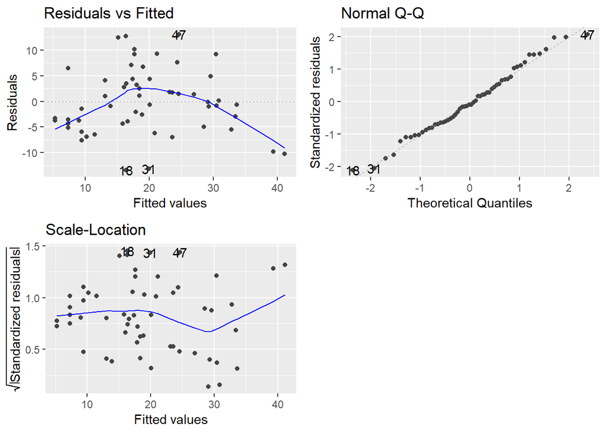

```r
autoplot(noIsol,c(1,2,3))
```

5. Determine the relative strength of the predictors in the model by rerunning it to calculate standardized partial regression coefficients.

```r
summary(smam <- lm(scale(abundance) ~ scale(grazing)+scale(logArea), data = birdDat))
```

```
##
## Call:
## lm(formula = scale(abundance) ~ scale(grazing) + scale(logArea),
##     data = birdDat)
##
## Residuals:
##     Min      1Q  Median      3Q     Max
## -1.2510 -0.4023 -0.0589  0.3845  1.2179
##
## Coefficients:
##                  Estimate Std. Error t value Pr(>|t|)
## (Intercept)    -5.348e-17  8.022e-02   0.000 1.000000
## scale(grazing) -3.910e-01  9.763e-02  -4.005 0.000195 ***
## scale(logArea)  5.214e-01  9.763e-02   5.341 1.98e-06 ***
## ---
## Signif. codes:  0 '***' 0.001 '**' 0.01 '*' 0.05 '.' 0.1 ' ' 1
##
## Residual standard error: 0.6003 on 53 degrees of freedom
## Multiple R-squared:  0.6527, Adjusted R-squared:  0.6396
## F-statistic: 49.81 on 2 and 53 DF,  p-value: 6.723e-13
```

6. Make a formal graph that shows how well the data fit the MAM.

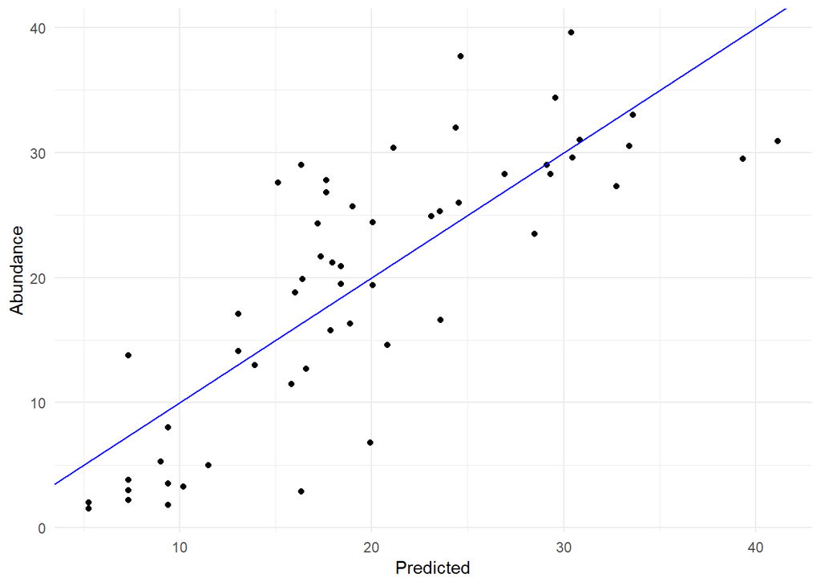

```r
birdDat <- birdDat %>% mutate(pred = fitted(noIsol))

ggplot(birdDat)+
  geom_point(aes(x=pred, y = abundance)) +
  geom_abline(intercept = 0, slope = 1, colour = "blue") +
  theme_minimal() +
  scale_y_continuous (name ="Abundance") +
  scale_x_continuous (name ="Predicted")
```

Figure 1. Abundance values vs abundance values predicted by the MAM of Abundance ~ logArea+grazing. Blue line is of formula y=1x+0, and represents a perfect match between predicted and actual abundance values.

7. Like backwards elimination, we begin model selection using AICc with a full model. Use the dredge() function to run all possible models and, for each, compute the log-likelihood, corrected AIC, DAIC, Akaike weight and r2. Express the regression parameters as standardized partial regression coefficients.

```r
options(na.action = "na.fail")
dd <- MuMIn::dredge(full, extra = "R^2", beta = "sd")
```

```
## Fixed term is "(Intercept)"
```

```r
print(dd, abbrev.names = F)
```

```
## Global model call: lm(formula = abundance ~ grazing + altitude_masl + logArea +
##     logLarge + logNear + nyrs_isol, data = birdDat)
## ---
## Model selection table
##    (Intercept) altitude_masl grazing logArea logLarge   logNear nyrs_isol
## 39           0               -0.2606  0.5423                      -0.1867
## 40           0       0.10480 -0.2194  0.5355                      -0.1904
## 7            0               -0.3910  0.5214
## 47           0               -0.2524  0.5866 -0.08816             -0.1654
## 55           0               -0.2656  0.5666          -0.078940   -0.1753
## 15           0               -0.3603  0.5835 -0.11730
## 38           0       0.14690          0.6168                      -0.2974
## 8            0       0.10010 -0.3541  0.5145
## 23           0               -0.3873  0.5523          -0.095420
## 37           0                        0.6503                      -0.3223
```

[output cut: 120 more lines]

8. What predictors are included in the “top model” and does this set of predictors differ from the MAM that you arrived at using backwards and forwards selection?

The top model includes Grazing, logArea and nyrs_Isol, a different set of predictors from our forwards and backwards selection MAM.

9. A common convention is to consider all models with DAIC ≤ 2 to be statistically indistinguishable. Let’s consider how useful this criterion is in this case. Use ggplot to make a scatterplot with the rank of each model in terms of AICc on the x-axis (ranked from lowest AICc to highest) and DAIC on the y-axis. Plot a red horizontal line at DAIC = 2 to indicate how many other models you should consider along with the top model. This graph requires a figure caption, etc. In the text of your R notebook, interpret this graph. Do you see any obvious breakpoints in DAIC that separate models into likely vs. unlikely groups? Do any of these break points correspond to DAIC ≤ 2?

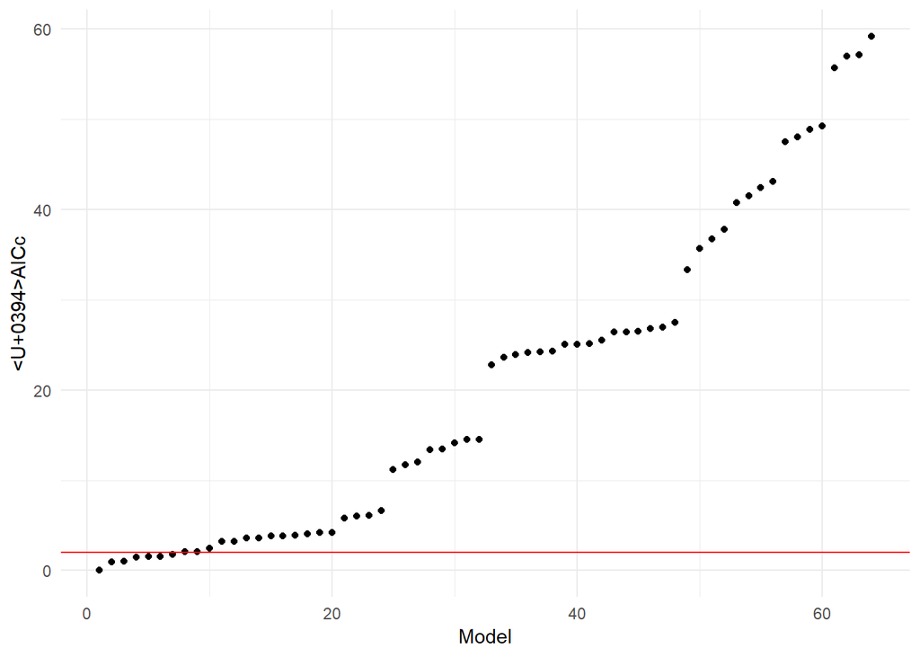

```r
ddr <- data.frame(model = seq(1:64), AICc = dd$AICc, delta = dd$delta,
                  weight = dd$weight, evid.ratio = max(dd$weight)/dd$weight)

ggplot(ddr)+
  geom_point(aes(x = model, y = delta))+
  geom_hline(yintercept = 2, colour = "red")+
  theme_minimal() +
  scale_y_continuous (name ="ΔAICc") +
  scale_x_continuous (name ="Model")
```

Figure 2. All possible linear models from the Birds in forest patches data set ranked from lowest (left) DAICc to highest (right), where the lowest is the most likely model to predict abundance. The red line is set to a DAIcc threshold of 2, with all points below the line having explanitory power not significantly different from that of the “best” model.

This graph shows that while only the first 7 models are statistically identical, having DAICc values below 2, the first 20-24 are all relatively well grouped with no obvious rapid increases in AICc to separate them. The first debatably clear break in AICc is after model 20, while there is a definite clear break after model 24. This suggests that although we are only taking the models below the arbitrary value of 2 that is commonly accepted in stats, the first 20-24 are also worth keeping in mind

10. Given the DAIC ≤ 2 criterion, how many other potential models should you consider along with the top model? Among this set of models, how frequently is each predictor included? Do the standardized partial regression coefficients of included predictors change much from model to model? Briefly describe the relevant trends.

General trends for standardized partial regression coeffecients are as follows: grazing seems to drop in explanitory power as more predictors are added to the model dropping from -0.39 in the grazing+logarea model down to -0.21 and -0.25 in both 4 predictor models. none of the other predictors seem to follow clear trends. nyrs seems to spike in explanitory power when altitude is added, and log area appears to on average increase in power when more predictors are added, but neither of these are clear cut.

11. Calculate evidence ratios for all potential models and interpret these values along with Akaike weights. How likely is it that the top model is the best model?

```r
(evid.ratio = max(dd$weight)/dd$weight)
```

```
##  model weights
##  [1]             1.000             1.590             1.639
##  [4]             2.092             2.171             2.210
##  [7]             2.396             2.781             2.795
## [10]             3.423             4.939             5.000
## [13]             6.022             6.079             6.823
## [16]             6.873             6.961             7.529
## [19]             8.024             8.032            18.342
## [22]            20.592            20.693            27.772
## [25]           264.899           347.658           400.703
## [28]           789.419           841.259          1162.548
## [31]          1393.829          1407.237         88498.179
## [34]        134632.449        155243.005        175469.431
## [37]        184085.377        190833.131        269933.699
## [40]        277276.004        284203.191        347664.423
## [43]        541894.737        550028.416        557844.962
## [46]        649101.506        703949.033        934737.143
## [49]      17391156.612      54734374.381      92975840.096
## [52]     162789218.246     692828638.857    1043973977.916
## [55]    1641726781.938    2291067421.053   20708202330.527
## [58]   26749354050.361   40889611688.644   48623579929.361
## [61] 1220030127616.871 2370595599663.339 2516806586802.062
## [64] 7006988638513.698
```

the top value has an Akaike weight of 0.147, suggesting a 14.7% chance of being the best model. In terms of evidence ratios, the top 7 models have evidence ratios of 1, 1.59, 1.64, 2.09, 2.17, 2.21, and 2.4. As the evidence ratio is the weight of the top model/the weight of the model you are looking at this means the top model is 1.59x, 1.64x, 2.09x, etc. more likely to be the best model than the other models in the top 7.

To summarize: the top model has an ~15% chance of being the best model and is ~1.6x more likely to be the best model then the 2nd best model.

12. Run this top model and use ggplot to create “added-variable” plots that show the partial relation between the response and each predictor. If there is more than one predictor, arrange all the plots together using plot_grid(). This is a formal graph requiring a figure caption, etc.

[figure not shown]

```r
selBirdDat <- birdDat %>% select(abundance, logArea,nyrs_isol, grazing)
#y axis
A_y.g <- residuals(lm(abundance ~ nyrs_isol + grazing,  data = selBirdDat))
A_a.g <- residuals(lm(abundance ~ logArea + grazing, data = selBirdDat))
A_a.y <- residuals(lm(abundance ~ logArea + nyrs_isol, data = selBirdDat))

#x axis residuals
a_y.g <- residuals(lm(logArea ~ nyrs_isol + grazing, data = selBirdDat))
y_a.g <- residuals(lm(nyrs_isol ~ logArea + grazing, data = selBirdDat))
g_a.y <- residuals(lm(grazing ~ logArea + nyrs_isol, data = selBirdDat))

datf <- data.frame(A_y.g,
                   A_a.g,
                   A_a.y,
                   a_y.g,
                   y_a.g,
                   g_a.y )

rm(A_y.g, A_a.g, A_a.y, a_y.g, y_a.g, g_a.y )

area <- ggplot(datf, aes(x=A_y.g, y=a_y.g)) +
  geom_point() +
  geom_smooth(method= "lm",se=T) +
  theme_minimal() +
  scale_y_continuous (name ="Abundance | Others") +
  scale_x_continuous (name = expression(paste("Fragment area (ha)"," (",log[10],") | Others" )))

years <- ggplot(datf, aes(x=A_a.g, y=y_a.g)) +
  geom_point() +
  geom_smooth(method= "lm",se=T) +
  theme_minimal() +
  scale_y_continuous (name ="") +
  scale_x_continuous (name ="Years isolated | Others")

grazing <- ggplot(datf, aes(x=A_a.y, y=g_a.y)) +
  geom_point() +
  geom_smooth(method= "lm",se=T) +
  theme_minimal() +
  scale_y_continuous (name ="Abundance | Others") +
  scale_x_continuous (name ="Grazing | Others")


ggarrange(area,years,grazing, labels =  c("A","B","C"))
```

13. Make sure that all the formal graphs asked for above are beautifully rendered with complete and informative figure legends. You should upload your file to the Assignment #6 OnQ dropbox by Saturday 7 March 2020 at 1159pm. As before, please submit a PDF version of your .html R notebook document called “StudentNumber_A6.pdf”, where the file name starts with your student number.